# opa

## Background

`opa` is an implementation of methods described in publications including Thorngate (1987) and [Grice et al. (2015)](https://doi.org/10.1177/2158244015604192). Thorngate (1987) attributes the original idea to:

Parsons, D. (1975). *The directory of tunes and musical themes*. S. Brown.

Ordinal pattern analysis may be useful as an alternative, or addition, to other methods of analyzing repeated measures data such as repeated measures ANOVA and mixed-effects models.

## Modeling repeated measures data

Once installed, you can load `opa` with

```r
library(opa)
```

### Data

For this example we will use childhood growth data reported by Potthoff & Roy (1964) consisting of measures of the distance between the pituitary and the pteryo-maxillary fissure. Distances were recorded in millimeters when each child was 8, 10, 12 and 14 years old. This is same data set available as `Orthodont` from the `nlme` package.

```r
str(pituitary)
```

```
#> 'data.frame':    108 obs. of  4 variables:
#>  $ distance  : num  26 25 29 31 21.5 22.5 23 26.5 23 22.5 ...
#>  $ age       : int  8 10 12 14 8 10 12 14 8 10 ...
#>  $ individual: Factor w/ 27 levels "1","2","3","4",..: 1 1 1 1 2 2 2 2 3 3 ...
#>  $ sex       : Factor w/ 2 levels "F","M": 2 2 2 2 2 2 2 2 2 2 ...
```

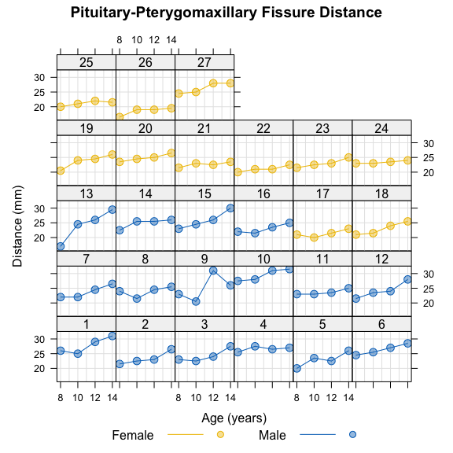

```r
xyplot(distance ~ age | individual, pituitary, type = c("g", "p", "l"),
       groups = sex, cex = 1.2, pch = 21,
       fill = c("#EFC00070", "#0073C270"), col = c("#EFC000", "#0073C2"),
       scales = list(x = list(at = c(8, 10, 12, 14))),
       xlab = "Age (years)", ylab = "Distance (mm)",
       main = "Pituitary-Pterygomaxillary Fissure Distance",
       key = list(space = "bottom", columns = 2,
                  text = list(c("Female", "Male")),
                  lines = list(col = c("#EFC000", "#0073C2")),
                  points = list(pch = 21, fill = c("#EFC00070", "#0073C270"),
                                col = c("#EFC000", "#0073C2"))))
```

#### Wide format

`opa` requires data in wide format, with one row per individual and one column per measurement time or condition.

```r
dat_wide <- reshape(data = pituitary,
                    direction = "wide",
                    idvar = c("individual", "sex"),
                    timevar = "age",
                    v.names = "distance")
```

```r
head(dat_wide)
```

```
#>    individual sex distance.8 distance.10 distance.12 distance.14
#> 1           1   M       26.0        25.0        29.0        31.0
#> 5           2   M       21.5        22.5        23.0        26.5
#> 9           3   M       23.0        22.5        24.0        27.5
#> 13          4   M       25.5        27.5        26.5        27.0
#> 17          5   M       20.0        23.5        22.5        26.0
#> 21          6   M       24.5        25.5        27.0        28.5
```

### Specifying a hypothesis

For this analysis we will assume a hypothesis of monotonic increase in distance with increasing age. This monotonic increase hypothesis can be encoded using the `hypothesis()` function.

```r
h1 <- hypothesis(c(1, 2, 3, 4), type = "pairwise")
```

Printing the hypothesis object shows that it consists of sub-hypotheses about six ordinal relations. In this case it is hypothesized that each of the six ordinal relations are increases, coded as `1`.

```r
print(h1)
```

```
#> ********** Ordinal Hypothesis **********
#> Hypothesis type: pairwise
#> Raw hypothesis:
#>  1 2 3 4
#> Ordinal relations:
#>  1 1 1 1 1 1
#> N conditions: 4
#> N hypothesised ordinal relations: 6
#> N hypothesised increases: 6
#> N hypothesised decreases: 0
#> N hypothesised equalities: 0
```

The hypothesis can also be visualized with the `plot()` function. Note that the y-axis is unitless; the vertical distance between points has no meaning. The information represented by the y-axis is relative: bigger, smaller or equal.

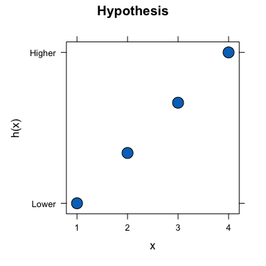

```r
plot(h1)
```

### Fitting an ordinal pattern analysis model

How well a hypothesis accounts for observed data can be quantified at the individual and group levels using the `opa()` function. The first required argument to `opa()` is a dataframe consisting of only the response variable columns. The second required argument is the hypothesis.

```r
m1 <- opa(dat_wide[,3:6], h1)
```

The results can be summarized using the `summary()` function.

```r
summary(m1)
```

```
#> Ordinal Pattern Analysis of 4 observations for 27 individuals in 1 group
#>
#> Between subjects results:
#>          PCC   cval
#> pooled 88.27 <0.001
#>
#> Within subjects results:
#>       PCC cval
#> 1   83.33 0.16
#> 2  100.00 0.04
#> 3   83.33 0.16
#> 4   66.67 0.40
#> 5   83.33 0.16
#> 6  100.00 0.06
#> 7   83.33 0.09
```

[output cut: 23 more lines]

The individual-level results can also be visualized using `plot()`.

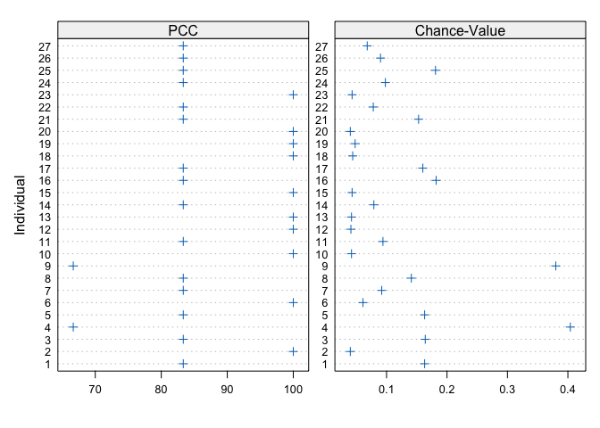

```r
plot(m1)
```

It is also possible to determine how well the hypothesis accounts for the data at the group level for each of the sub-hypotheses using the `compare_conditions()` function.

```r
compare_conditions(m1)
```

```
#> Pairwise PCCs:
#>        1      2      3 4
#> 1      -      -      - -
#> 2 66.667      -      - -
#> 3    100 77.778      - -
#> 4    100 96.296 88.889 -
#>
#> Pairwise chance values:
#>        1      2     3 4
#> 1      -      -     - -
#> 2  0.013      -     - -
#> 3 <0.001 <0.001     - -
#> 4 <0.001 <0.001 0.001 -
```

These results indicate that the hypothesis accounts least well for the relationship between the first two measurement times.

### Comparing hypotheses

The output of `compare_conditions()` indicates that it may be informative to consider a second, non-monotonic hypothesis:

```r
h2 <- hypothesis(c(2, 1, 3, 4))
```

`h2` contains the sub-hypothesis that the second measurement, at age 10, may be shorter than the first measurement taken at age 8.

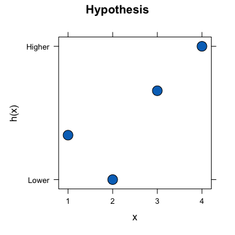

```r
plot(h2)
```

The hypothesized decrease between measurements at ages 8 and 10 is encoded as `-1`.

```r
print(h2)
```

```
#> ********** Ordinal Hypothesis **********
#> Hypothesis type: pairwise
#> Raw hypothesis:
#>  2 1 3 4
#> Ordinal relations:
#>  -1 1 1 1 1 1
#> N conditions: 4
#> N hypothesised ordinal relations: 6
#> N hypothesised increases: 5
#> N hypothesised decreases: 1
#> N hypothesised equalities: 0
```

To assess the adequacy of `h2` we fit a second `opa()` model, this time passing `h2` as the second argument.

```r
m2 <- opa(dat_wide[,3:6], h2)
```

The `compare_hypotheses()` function can then be used to compare how well two hypothese account for the observed data.

```r
(comp_h1_h2 <- compare_hypotheses(m1, m2))
```

```
#> ********* Hypothesis Comparison **********
#> H1: 1 2 3 4
#> H2: 2 1 3 4
#> H1 PCC: 88.2716
#> H2 PCC: 80.8642
#> PCC difference: 7.407407
#> cval: 0.294
#> Comparison type: two-tailed
```

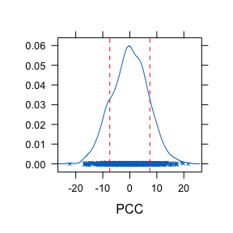

```r
plot(comp_h1_h2)
```

### Comparing groups

So far the analyses have not considered any possible differences between males and females in terms of how well the hypotheses account for the data. It is possible that a given hypothesis account better for males than for females, or vice-versa. A model which accounts for groups within the data can be fitted by passing a factor vector or dataframe column to the `group` argument.

```r
m3 <- opa(dat_wide[,3:6], h1, group = dat_wide$sex)
```

The `plot()` function can be used to get a first sense of how PCCs and chance-values differ between groups.

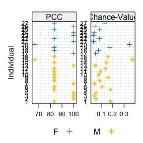

```r
plot(m3)
```

There is not a clearly visible pattern that appears to distinguish males from females. The `compare_groups()` function may be used to more precisely quantify the difference in hypothesis performance between the groups within the data.

```r
(comp_m_f <- compare_groups(m3, "M", "F"))
```

```
#> ********* Group Comparison **********
#> Group 1: M
#> Group 2: F
#> Group 1 PCC: 87.5
#> Group 2 PCC: 89.39394
#> PCC difference: 1.893939
#> cval: 0.866
#> Comparison type: two-tailed
```

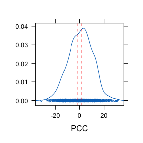

```r
plot(comp_m_f)
```

### Difference thresholds

Each of the above models has treated any numerical difference in the distance data as a true difference. However, we may wish to treat values that differ by some small amount as equivalent. In this way we may define a threshold of practical or clinical significance. For example, we may decide to consider only differences of at least 1 mm. This can be achieved by passing a threshold value of `1` using the `diff_threshold` argument.

```r
m4 <- opa(dat_wide[,3:6], h1, group = dat_wide$sex, diff_threshold = 1)
```

Setting the difference threshold to 1 mm results in a greater difference in hypothesis performance between males and females.

```r
group_results(m4)
```

```
#>     PCC   cval
#> F 54.55 <0.001
#> M 71.88 <0.001
```

However, `compare_groups()` reveals that even this larger difference could occur quite frequently by chance.

```r
compare_groups(m4, "M", "F")
```

```
#> ********* Group Comparison **********
#> Group 1: M
#> Group 2: F
#> Group 1 PCC: 71.875
#> Group 2 PCC: 54.54545
#> PCC difference: 17.32955
#> cval: 0.193
#> Comparison type: two-tailed
```

## References

Grice, J. W., Craig, D. P. A., & Abramson, C. I. (2015). A Simple and Transparent Alternative to Repeated Measures ANOVA. SAGE Open, 5(3), 215824401560419. https://doi.org/10.1177/2158244015604192

Parsons, D. (1975). *The directory of tunes and musical themes*. S. Brown.

Potthoff, R. F., & Roy, S. N. (1964). A Generalized Multivariate Analysis of Variance Model Useful Especially for Growth Curve Problems. Biometrika, 51(3/4), 313–326. https://doi.org/10.2307/2334137

Thorngate, W. (1987). Ordinal Pattern Analysis: A Method for Assessing Theory-Data Fit. Advances in Psychology, 40, 345–364. https://doi.org/10.1016/S0166-4115(08)60083-7